# Learning Challenge #3

Aubrey Coyne

### Load the Data

```r
# This code chunk may take a little while to run because you're pulling in a lot of data!
## Load our tidyverse library
options(scipen=999)
library(tidyverse)
## Load data for the award_totals object
temp_file <- tempfile(fileext = ".zip")
download.file("https://zamith.umasscreate.net/data/usaspending_financial_assistance_totals.zip", temp_file, mode = "wb")
award_totals <- read_csv(temp_file)
rm(temp_file)

## Load data for the hampshire_awards_sample object
temp_file <- tempfile(fileext = ".zip")
download.file("https://zamith.umasscreate.net/data/usaspending_financial_assistance_hampshire_sample.zip", temp_file, mode = "wb")
hampshire_awards_sample <- read_csv(temp_file)
rm(temp_file)

## Load data for the hampshire_awards_top object
temp_file <- tempfile(fileext = ".zip")
download.file("https://zamith.umasscreate.net/data/usaspending_financial_assistance_hampshire_top.zip", temp_file, mode = "wb")
hampshire_awards_top <- read_csv(temp_file)
rm(temp_file)
```

### Massachusetts Relies on $2 Billion in Funding from Department of Education in Addition to $2 Billion in K-12 Support

**March 20, 2025** – President Donald Trump signed an [executive order](https://www.whitehouse.gov/presidential-actions/2025/03/improving-education-outcomes-by-empowering-parents-states-and-communities/) to dismantle the Department of Education, aiming to return authority over education to the states. In a [statement released by the White House](https://www.whitehouse.gov/articles/2025/03/on-education-president-trump-knows-we-can-do-better/), the decision was justified by the education system failing students in the past decades, citing the low student-test-scores as evidence. The Department of Education has used $3 trillion of federal funding with “virtually nothing to show for it,” according to the Trump administration.

However, Massachusetts Gov. Maura Healey, said in a [March press release](https://www.mass.gov/news/healey-driscoll-administration-sounds-alarm-over-donald-trumps-dismantling-of-us-department-of-education) that students rely on this funding. “This will mean bigger class sizes, cancelled after school programs and less support for our students, especially those who live in rural communities or have special needs,” she said.

How exactly would a rural community, like Amherst, be affected without funding from the Department of Education?

**Massachusetts Funding from the Department of Education**

Massachusetts elementary and secondary schools receive more than $2 billion annually from the Department of Education, according to the [press release from the Healey-Driscoll Administration.](https://www.mass.gov/news/healey-driscoll-administration-sounds-alarm-over-donald-trumps-dismantling-of-us-department-of-education) Massachusetts would not be able to replace the entirety of this funding if the department is eliminated, the press release added.

The top funding in dollar amount that Amherst received from the Department of Education 2024 within the Hampshire County top awards include Pell Grants, research, work study, supplemental opportunity grants, special education, child care, TRIO Upward Bound, and teacher quality grants.

Pell Grants make up the clear majority of the funding. In 2024, the Department of Education allocated over $120 million for Pell Grants that directly go to Amherst students.

Pell Grants are given to mostly Undergraduate students who “display exceptional financial need,” according to [Federal Student Aid run by the Department of Education.](https://studentaid.gov/understand-aid/types/grants/pell) Many students rely on this funding to afford and therefore attend college.

Upward Bound also receives considerable funding from the Department of Education and would be vulnerable to the dismantling of the department. In 2024, the program in Amherst received almost $1 million directly from the Department of Education.

[Upward Bound](https://www.ed.gov/grants-and-programs/grants-higher-education/trio/upward-bound-program) aims to support student success in secondary school and eventually to higher education. The program serves students form low-income families or first generation students

Upward Bound has local ties in bringing students from [Springfield to University of Massachusetts Amherst](https://www.umass.edu/cmass/upward-bound) for campus experiences. The program also tutors and mentors students in school subjects and standardized testing, while also focusing on celebrating students’ culture and identities. The funding allows this program to be free for students and provide students with a stipend to alleviate the burden of students missing paid-work to attend the program.

Although the Trump administration has promised to keep Pell Grants and special education funding, programs such as Upward Bound and research that supports students directly in Western Massachusetts would be in jeopardy.

Just in 2025, the Department of Education voted Massachusetts the number one state in education. The success can be attributed to Massachusetts’ dedication to investing in schools, according to a [January press release from the Healey-Driscoll Administration.](https://www.mass.gov/news/massachusetts-ranks-1-in-national-education-assessment#:~:text=“Massachusetts%20is%20%231%20in%20education,to%20succeed%20in%20the%20future)

**How does Massachusetts and UMass Amherst’s funding from the Department of Education compare to other states and colleges?**

Massachusetts received a total of over $4 billion from the Department of Education in 2024, according to data from USASpending.gov. In comparison to other New England states, Massachusetts received the most funding from the Department of Education in 2024. Connecticut ranked second, receiving about $2.4 billion from the Department of Education in 2024.

In 2024, UMass Amherst received the third-largest award from the Department of Education among organizations in Massachusetts, totaling just above $122 million. University of Massachusetts Boston received just approximately $24 million more with a total award of about $146 million.

The largest award in the state from the Department of Education went to the Massachusetts department of elementary and secondary education, which received just over $2 billion– consistent with what Gov. Healey said in the March press release. Based on the Massachusetts total allocation, nearly $2 billion more was given from the Department of Education to programs and colleges that were not included in this $2 billion for elementary and secondary education.

Needless to say, there is a lot at stake with the fate of the Department of Education for students across the country, including locally in Amherst.

**What now?**

Nationwide, there have been marches protesting the Trump administration’s initiative to dismantle the Department of Education. Just this past Saturday, rallies were held with the title “Hands Off” to condemn the recent actions of President Trump and Elon Musk.

One of the key-points in this protest was the message, “Hands off our schools.”

“We need to stand up like this often to show witness to what’s happening. To intervene when we’re needed and to protect our neighbors,” Rep. Mindy Domb, an organizer for the Amherst “Hands Off” protest said in an interview for [New England Public Media.](https://www.nhpr.org/2025-04-05/western-mass-protestors-join-others-around-the-nation-rallying-against-trump)

Despite the executive order, reduced funding, and staff firings, the Department of Education still stands as of today. The department cannot be shut down without Congressional approval. Citizens can call state representatives and senators to demand push-back to President Trump’s executive order.

Both Democrats and Republicans agree that students are being failed by the education system. Abolishing the Department of Education would cut funding for students that can’t be replaced, as Gov. Healey warned Massachusetts families.

The inevitable question becomes: is reducing funding for students the solution to a failing education system?

### Methodological Appendix

#### Graphing which programs in Amherst recieved the most funding in 2024 from the Department of Education

This bar graph is taking in data from the top awards given to Hampshire county. It is mainly showing the significant amount of money Amherst received for Pell Grants in 2024.

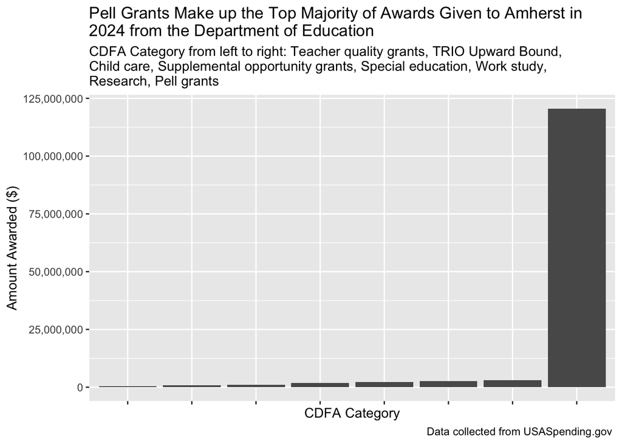

```r
#Load in data frame
hampshire_awards_top %>%
  #Only include data that was awarded to Amherst from the Department of Education in 2024
  filter(awarding_agency_name=="Department of Education",action_date_fiscal_year=="2024",recipient_city_name=="AMHERST")%>%
  #Combine the awards to the same program to calculate a total for each distinct program
  group_by(cfda_title)%>%
summarise(total_obligated_amount = sum(total_obligated_amount, na.rm = TRUE))%>%
  #Arrange the total dollar amount by highest to lowest
  arrange(desc(total_obligated_amount)) %>%
  #Create a bar graph
  ggplot(aes(x=reorder(cfda_title, total_obligated_amount), y=total_obligated_amount))+
   theme(axis.text.x = element_blank())+

  geom_col()+
  labs(x="CDFA Category", y="Amount Awarded ($)", title= "Pell Grants Make up the Top Majority of Awards Given to Amherst in\n2024 from the Department of Education", subtitle="CDFA Category from left to right: Teacher quality grants, TRIO Upward Bound,\nChild care, Supplemental opportunity grants, Special education, Work study,\nResearch, Pell grants ", caption="Data collected from USASpending.gov ")+
scale_y_continuous(labels = scales::label_comma())
```

#### Graphing which programs, besides Pell Grants, in Amherst recieved the most funding in 2024 from the Department of Education

This bar graph is taking in data from the top awards given to Hampshire county. It is mainly showing how Amherst still received considerable funding awards alongside the Pell Grants because the last bar graph made the other categories seem insignificant.

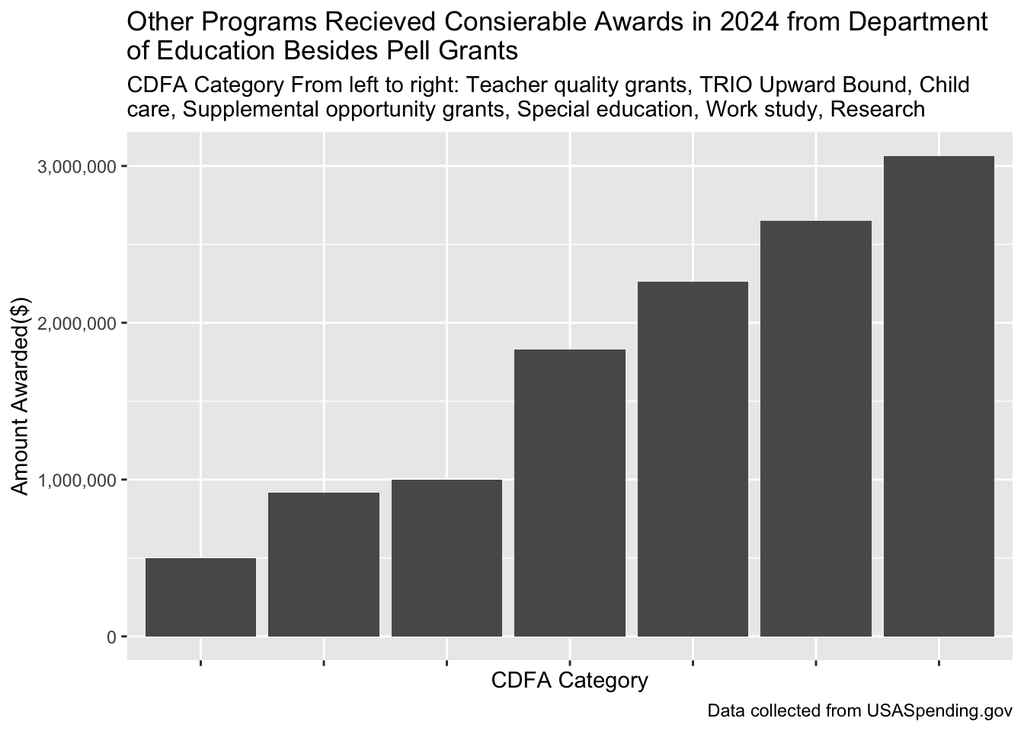

```r
#Load in data Frame
hampshire_awards_top %>%
  #Only include data that was awarded to Amherst from the Department of Education in 2024 and exclude data given to Pell grants
  filter(awarding_agency_name=="Department of Education", action_date_fiscal_year=="2024", recipient_city_name=="AMHERST", cfda_title != "FEDERAL PELL GRANT PROGRAM")%>%
  group_by(cfda_title)%>%
  #Combine the awards to the same program to calculate a total for each distinct program
summarise(total_obligated_amount = sum(total_obligated_amount, na.rm = TRUE))%>%
  #Arrange the total dollar amount by highest to lowest
  arrange(desc(total_obligated_amount))%>%
  #Create a bar graph
  ggplot(aes(x=reorder(cfda_title, total_obligated_amount), y=total_obligated_amount))+
  theme(axis.text.x = element_blank())+
  geom_col()+
  labs(x="CDFA Category", y="Amount Awarded($)", title= "Other Programs Recieved Consierable Awards in 2024 from Department\nof Education Besides Pell Grants", subtitle="CDFA Category From left to right: Teacher quality grants, TRIO Upward Bound, Child\ncare, Supplemental opportunity grants, Special education, Work study, Research ", caption="Data collected from USASpending.gov")+
  scale_y_continuous(labels = scales::label_comma())
```

#### Calculating the dollar amount of top awards Amherst recieved in 2024 from the Department of Education

This table is taking in data from the top awards given to Hampshire county. It shows specifically how much money each of the categories received, since this exact amount is not included in the bar graphs.

```r
#Load in data frame
hampshire_awards_top %>%
  #Only include data that was awarded to Amherst from the Department of Education in 2024
  filter(awarding_agency_name=="Department of Education", action_date_fiscal_year=="2024", recipient_city_name=="AMHERST")%>%
  #Combine the awards to the same program to calculate a total for each distinct program
  group_by(cfda_title)%>%
summarise(total_obligated_amount = sum(total_obligated_amount, na.rm = TRUE))%>%
  #Arrange the total dollar amount by highest to lowest
  arrange(desc(total_obligated_amount))
```

| cfda_title | total_obligated_amount |
| --- | --- |
| FEDERAL PELL GRANT PROGRAM | 120509430 |
| EDUCATION RESEARCH, DEVELOPMENT AND DISSEMINATION | 3063603 |
| FEDERAL WORK-STUDY PROGRAM | 2651320 |
| SPECIAL EDUCATION - PERSONNEL DEVELOPMENT TO IMPROVE SERVICES AND RESULTS FOR CHILDREN WITH DISABILITIES | 2259219 |
| FEDERAL SUPPLEMENTAL EDUCATIONAL OPPORTUNITY GRANTS | 1828988 |
| CHILD CARE ACCESS MEANS PARENTS IN SCHOOL | 1000800 |
| TRIO UPWARD BOUND | 916495 |
| TEACHER QUALITY PARTNERSHIP GRANTS | 497760 |

#### Calculating how much money each New England state recieved in 2024 from the Department of Education

This table is taking in data from the total awards given by the Department of Education. It shows specifically how much money each state received from the highest total amount to the lowest.

```r
 #Load in data frame
award_totals %>%
  #Only included data that was awarded by the Department of Education in 2024 to New England states
  filter(awarding_agency_name=="Department of Education", action_date_fiscal_year=="2024", recipient_state_code %in% c ("MA", "CT","RI", "ME", "VT", "NH"))%>%
  #Combine the awards to the same program to calculate a total for each distinct state
  group_by(recipient_state_code)%>%
  summarize(total=sum(total_obligated_amount))%>%
  #Arrange the total dollar amount by highest to lowest
  arrange(desc(total))
```

| recipient_state_code | total |
| --- | --- |
| MA | 4099452974 |
| CT | 2448941508 |
| NH | 1701666095 |
| ME | 804049837 |
| RI | 669919361 |
| VT | 506112362 |

#### Graphing how much money each New England state recieved in 2024 from the Department of Education

This bar graph is taking in data from the total awards given by the Department of Education. It shows visually how much money each state received from the highest total amount to the lowest. The graph specifically shows that Massachusetts received the most funding out the six states.

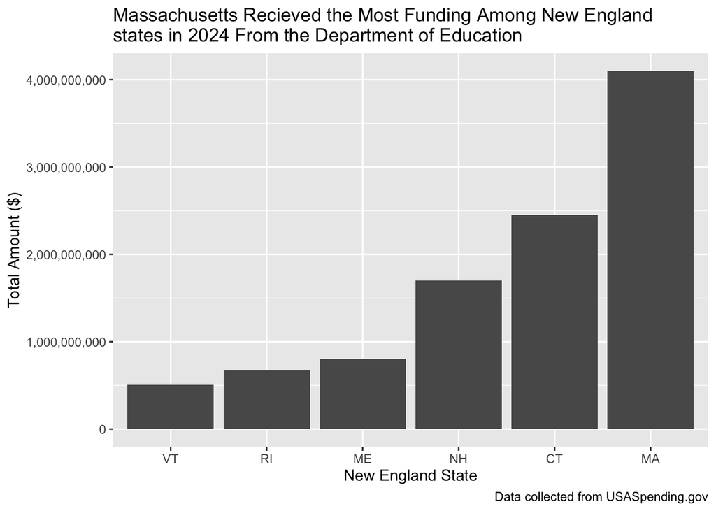

```r
 #Load in data frame
award_totals %>%
  #Only included data that was awarded by the Department of Education in 2024 to New England states
  filter(awarding_agency_name=="Department of Education", action_date_fiscal_year=="2024", recipient_state_code %in% c ("MA", "CT","RI", "ME", "VT", "NH"))%>%
  #Combine the awards to the same program to calculate a total for each distinct state
  group_by(recipient_state_code)%>%
  summarize(total=sum(total_obligated_amount))%>%
  #Arrange the total dollar amount by highest to lowest
  arrange(desc(total))%>%
#Create a bar graph
  ggplot(aes(x=reorder(recipient_state_code, total), y=total))+
  geom_col()+
  labs(x="New England State", y="Total Amount ($)", title="Massachusetts Recieved the Most Funding Among New England \nstates in 2024 From the Department of Education", caption="Data collected from USASpending.gov")+
  scale_y_continuous(labels = scales::label_comma())
```

#### Graphing the top 5 funding awards in 2024 from the Department of Education

This bar graph is taking in data from the total awards given by the Department of Education. It shows that the Massachusetts Department of Elementary & Secondary Education received significant funding compared to the other top 4 funding awards.

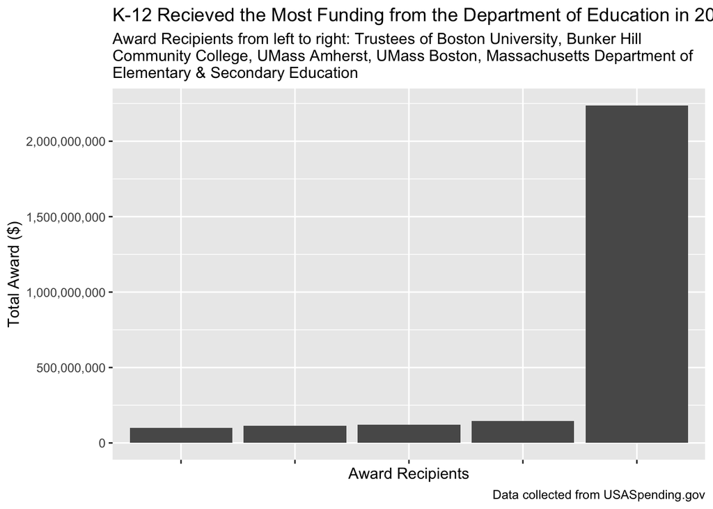

```r
#Load in data frame
award_totals %>%
  #Only included data that was awarded by the Department of Education in 2024 to Massachusetts
  filter(awarding_agency_name == "Department of Education",
         action_date_fiscal_year == "2024", recipient_state_code=="MA")%>%
 #Take the data of the top 5 most funded recipients
  slice_max(total_obligated_amount, n=5)%>%
  #Create a bar graph
  ggplot(aes(x = reorder(recipient_name, total_obligated_amount), y = total_obligated_amount)) +
  labs(title = "K-12 Recieved the Most Funding from the Department of Education in 2024", subtitle= "Award Recipients from left to right: Trustees of Boston University, Bunker Hill \nCommunity College, UMass Amherst, UMass Boston, Massachusetts Department of\nElementary & Secondary Education", x = "Award Recipients", y = "Total Award ($)", caption="Data collected from USASpending.gov")+
  geom_col(show.legend = FALSE)+
  theme(axis.text.x = element_blank())+
  scale_y_continuous(labels = scales::label_comma())
```

#### Graphing the top 5 funding awards, excluding the Massachusetts Department of Elementary & Secondary Education, in 2024 from the Department of Education

This bar graph is taking in data from the total awards given by the Department of Education. It shows that although the Massachusetts Department of Elementary & Secondary Education received significant funding, there is still a considerable amount of funding other schools and programs rely on from the Department of Education.

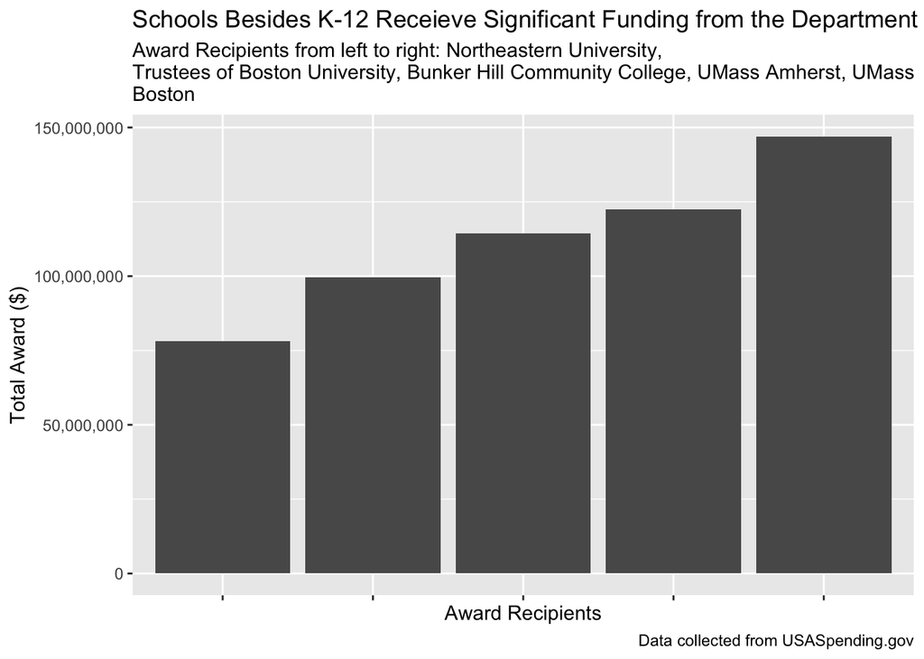

```r
#Load in data frame
award_totals %>%
  #Only included data that was awarded by the Department of Education in 2024 to Massachusetts and exclude data from the Massachusetts Department of Elementary and Secondary Education
  filter(awarding_agency_name == "Department of Education",
         action_date_fiscal_year == "2024", recipient_state_code=="MA", recipient_name!="MASSACHUSETTS DEPARTMENT OF ELEMENTARY & SECONDARY EDUCATION")%>%
 #Take the data of the top 5 most funded recipients
  slice_max(total_obligated_amount, n=5)%>%
  #Create a bar graph
  ggplot(aes(x = reorder(recipient_name, total_obligated_amount), y = total_obligated_amount)) +
  labs(title = "Schools Besides K-12 Receieve Significant Funding from the Department of Education", subtitle= "Award Recipients from left to right: Northeastern University,\nTrustees of Boston University, Bunker Hill Community College, UMass Amherst, UMass\nBoston", x = "Award Recipients", y = "Total Award ($)", scales::label_comma(), caption="Data collected from USASpending.gov")+
  geom_col(show.legend = FALSE)+
  theme(axis.text.x = element_blank())+
  scale_y_continuous(labels = scales::label_comma())
```

#### Calculating the top 6 funding awards in 2024 from the Department of Education

This table is taking in data from the total awards given by the Department of Education. It gives the specific total amount each recipient received from the data in the last two bar charts.

```r
#Load in data frame
award_totals %>%
  #Only included data that was awarded by the Department of Education in 2024 to Massachusetts
  filter(awarding_agency_name == "Department of Education",
         action_date_fiscal_year == "2024", recipient_state_code=="MA")%>%
  #Only show the columns with the recipient name and total amount awarded
  select(recipient_name, total_obligated_amount)%>%
  #Take the data of the top 6 most funded recipients
 slice_max(total_obligated_amount, n=6)
```

| recipient_name | total_obligated_amount |
| --- | --- |
| MASSACHUSETTS DEPARTMENT OF ELEMENTARY & SECONDARY EDUCATION | 2237441572 |
| UNIVERSITY OF MASS AT BOSTON | 146982208 |
| UNIVERSITY OF MASSACHUSETTS | 122525951 |
| BUNKER HILL COMMUNITY COLLEGE | 114324320 |
| TRUSTEES OF BOSTON UNIVERSITY | 99697869 |
| NORTHEASTERN UNIVERSITY | 78089358 |